# Introduction of KNN Algorithm

1. K-Nearest Neighbour is one of the simplest Machine Learning algorithms based on Supervised Learning technique.
2. K-NN algorithm assumes the similarity between the new case/data and available cases and put the new case into the category that is most similar to the available categories.
3. K-NN algorithm stores all the available data and classifies a new data point based on the similarity. This means when new data appears then it can be easily classified into a well suite category by using K- NN algorithm.
4. K-NN algorithm can be used for Regression as well as for Classification but mostly it is used for the Classification problems.
5. K-NN is a non-parametric algorithm, which means it does not make any assumption on underlying data.
6. It is also called a lazy learner algorithm because it does not learn from the training set immediately instead it stores the dataset and at the time of classification, it performs an action on the dataset.
7. KNN algorithm at the training phase just stores the dataset and when it gets new data, then it classifies that data into a category that is much similar to the new data.
8. Example: Suppose, we have an image of a creature that looks similar to cat and dog, but we want to know either it is a cat or dog. So for this identification, we can use the KNN algorithm, as it works on a similarity measure. Our KNN model will find the similar features of the new data set to the cats and dogs images and based on the most similar features it will put it in either cat or dog category

Source : [Java T point](https://www.javatpoint.com/k-nearest-neighbor-algorithm-for-machine-learning)

[figure not shown]

# How does K-NN work?

The K-NN working can be explained on the basis of the below algorithm:

Step-1: Select the number K of the neighbors

Step-2: Calculate the Euclidean distance of K number of neighbors

Step-3: Take the K nearest neighbors as per the calculated Euclidean distance.

Step-4: Among these k neighbors, count the number of the data points in each category.

Step-5: Assign the new data points to that category for which the number of the neighbor is maximum.

Step-6: Our model is ready

Source : [Java T point](https://www.javatpoint.com/k-nearest-neighbor-algorithm-for-machine-learning)

# Some points about KNN

1. Distance is the most important parameter.
2. Each of the training data consists of a label data association with it, either +ive or -ive. Although, KNN also supports multiclass classification.
3. We are also given a single number k this number decides how many neighbors influence the classification. This is usually a odd number.
4. We will calculate the Euclidean distance between the data points. The Euclidean distance is the distance between two points, which we have already studied in geometry. It can be calculated as:

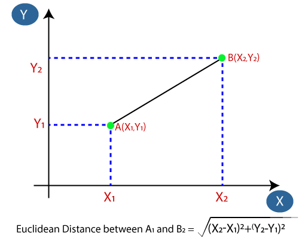

# Problem

We have a dataset of social network ads & the our task is:

->Data Pre-processing step

->Fitting the K-NN algorithm to the Training set

->Predicting the test result

->Test accuracy of the result(Creation of Confusion matrix)

->Visualizing the test set result.

->Predict for scoring query

# Making our Data Ready for Training

Mounting google drive to clone dataset from github

```python
from google.colab import drive
drive.mount('/content/drive')
```

cloning dataset directly in google drive

```python
# changing current directory
%cd /content/drive/MyDrive

# cloning start
!git clone https://github.com/Hunter-420/KNN-Algorithm-Intro-Project.git
```

```
/content/drive/MyDrive
Cloning into 'KNN-Algorithm-Intro-Project'...
remote: Enumerating objects: 7, done.
remote: Counting objects: 100% (7/7), done.
remote: Compressing objects: 100% (6/6), done.
remote: Total 7 (delta 0), reused 0 (delta 0), pack-reused 0
Unpacking objects: 100% (7/7), done.
```

```python
import pandas as pd
import numpy as np
import matplotlib.pyplot as plt
```

```python
data_set=pd.read_csv("/content/drive/MyDrive/KNN-Algorithm-Intro-Project/Social Network Ads Dataset/Social_Network_Ads.csv")
```

```python
data_set.head(15)
```

|  | Age | EstimatedSalary | Purchased |
| --- | --- | --- | --- |
| 0 | 19 | 19000 | 0 |
| 1 | 35 | 20000 | 0 |
| 2 | 26 | 43000 | 0 |
| 3 | 27 | 57000 | 0 |
| 4 | 19 | 76000 | 0 |
| 5 | 27 | 58000 | 0 |
| 6 | 27 | 84000 | 0 |
| 7 | 32 | 150000 | 1 |
| 8 | 25 | 33000 | 0 |
| 9 | 35 | 65000 | 0 |
| 10 | 26 | 80000 | 0 |
| 11 | 26 | 52000 | 0 |
| 12 | 20 | 86000 | 0 |
| 13 | 32 | 18000 | 0 |
| 14 | 18 | 82000 | 0 |

There are mainly two types of variable present in our dataset:

1. Input variables
2. Output Variable

In KNN Algorithm we split those variables. In above dataset "Age" & "EstimatedSalary" are the input variables and "purchased" is the output variable. According to input variables our output variable change.

We can also say that our purchased column is dependent with age & EstimatedSsalary column

Let's start the spliting process

```python
data_set.iloc[:,0:2]
```

|  | Age | EstimatedSalary |
| --- | --- | --- |
| 0 | 19 | 19000 |
| 1 | 35 | 20000 |
| 2 | 26 | 43000 |
| 3 | 27 | 57000 |
| 4 | 19 | 76000 |
| ... | ... | ... |
| 395 | 46 | 41000 |
| 396 | 51 | 23000 |
| 397 | 50 | 20000 |
| 398 | 36 | 33000 |
| 399 | 49 | 36000 |

400 rows × 2 columns

Converting above pandas dataset to numpy array

```python
x=data_set.iloc[:,0:2].values
```

```python
x
```

```
array([[    19,  19000],
       [    35,  20000],
       [    26,  43000],
       [    27,  57000],
       [    19,  76000],
       [    27,  58000],
       [    27,  84000],
       [    32, 150000],
       [    25,  33000],
       [    35,  65000],
       [    26,  80000],
       [    26,  52000],
       [    20,  86000],
       [    32,  18000],
       [    18,  82000],
       [    29,  80000],
       [    47,  25000],
       [    45,  26000],
       [    46,  28000],
       [    48,  29000],
       [    45,  22000],
       [    47,  49000],
       [    48,  41000],
       [    45,  22000],
       [    46,  23000],
       [    47,  20000],
       [    49,  28000],
       [    47,  30000],
       [    29,  43000],
       [    31,  18000],
       [    31,  74000],
       [    27, 137000],
       [    21,  16000],
       [    28,  44000],
       [    27,  90000],
       [    35,  27000],
       [    33,  28000],
       [    30,  49000],
       [    26,  72000],
       [    27,  31000],
```

[output cut: 345 more lines]

```
       [    56,  60000],
       [    49,  39000],
       [    39,  71000],
       [    47,  34000],
       [    48,  35000],
       [    48,  33000],
       [    47,  23000],
       [    45,  45000],
       [    60,  42000],
       [    39,  59000],
       [    46,  41000],
       [    51,  23000],
       [    50,  20000],
       [    36,  33000],
       [    49,  36000]])
```

Now we are going to check the size of the array

```python
x.shape
```

```
(400, 2)
```

```python
data_set.iloc[:,-1]
```

```
0      0
1      0
2      0
3      0
4      0
      ..
395    1
396    1
397    1
398    0
399    1
Name: Purchased, Length: 400, dtype: int64
```

We got a last coumn & again we convert it into the numpy array

```python
y=data_set.iloc[:,-1].values
```

```python
y
```

```
array([0, 0, 0, 0, 0, 0, 0, 1, 0, 0, 0, 0, 0, 0, 0, 0, 1, 1, 1, 1, 1, 1,
       1, 1, 1, 1, 1, 1, 0, 0, 0, 1, 0, 0, 0, 0, 0, 0, 0, 0, 0, 0, 0, 0,
       0, 0, 0, 0, 1, 0, 0, 0, 0, 0, 0, 0, 0, 0, 0, 0, 0, 0, 0, 1, 0, 0,
       0, 0, 0, 0, 0, 0, 0, 0, 0, 1, 0, 0, 0, 0, 0, 0, 0, 0, 0, 1, 0, 0,
       0, 0, 0, 0, 0, 0, 0, 0, 0, 1, 0, 0, 0, 0, 0, 1, 0, 0, 0, 0, 0, 0,
       0, 0, 0, 0, 0, 0, 0, 0, 0, 0, 0, 0, 0, 0, 0, 0, 0, 0, 0, 0, 0, 0,
       0, 0, 0, 0, 0, 1, 0, 0, 0, 0, 0, 0, 0, 0, 1, 0, 0, 0, 0, 0, 0, 0,
       0, 0, 0, 0, 0, 1, 1, 0, 0, 0, 0, 0, 0, 0, 1, 0, 0, 0, 0, 0, 0, 0,
       0, 0, 0, 0, 0, 0, 1, 0, 0, 0, 0, 0, 0, 0, 0, 0, 0, 0, 0, 0, 0, 0,
       0, 0, 0, 0, 1, 0, 1, 0, 1, 0, 1, 0, 1, 1, 0, 0, 0, 1, 0, 0, 0, 1,
       0, 1, 1, 1, 0, 0, 1, 1, 0, 1, 1, 0, 1, 1, 0, 1, 0, 0, 0, 1, 1, 0,
       1, 1, 0, 1, 0, 1, 0, 1, 0, 0, 1, 1, 0, 1, 0, 0, 1, 1, 0, 1, 1, 0,
       1, 1, 0, 0, 1, 0, 0, 1, 1, 1, 1, 1, 0, 1, 1, 1, 1, 0, 1, 1, 0, 1,
       0, 1, 0, 1, 1, 1, 1, 0, 0, 0, 1, 1, 0, 1, 1, 1, 1, 1, 0, 0, 0, 1,
       1, 0, 0, 1, 0, 1, 0, 1, 1, 0, 1, 0, 1, 1, 0, 1, 1, 0, 0, 0, 1, 1,
       0, 1, 0, 0, 1, 0, 1, 0, 0, 1, 1, 0, 0, 1, 1, 0, 1, 1, 0, 0, 1, 0,
       1, 0, 1, 1, 1, 0, 1, 0, 1, 1, 1, 0, 1, 1, 1, 1, 0, 1, 1, 1, 0, 1,
       0, 1, 0, 0, 1, 1, 0, 1, 1, 1, 1, 1, 1, 0, 1, 1, 1, 1, 1, 1, 0, 1,
       1, 1, 0, 1])
```

# Divide the whole Dataset into two parts for cross validation

1. Training
2. Test

To do that we use sklearn library to split our dataset into training & test data set. We use 20% data as a test data & remaining data use as a training data

```python
from sklearn.model_selection import train_test_split
x_train,x_test,y_train,y_test=train_test_split(x,y,test_size=0.20)
```

In above code *test_size=0.20* specify the 20% data is a **test data**. Now we quickly check the size of the remaining **training data**

```python
x_train.shape
```

```
(320, 2)
```

Our row reduced from **400** to **320** because we have only **80%** data as a **training data**

```python
x_test.shape
```

```
(80, 2)
```

This is our test data where we have **80** row which is the **20%** of our total dataset. We have sucessfully split train test data & Next thing is that **Standard Scaling**

# Standard Scaling & Training our data

```python
data_set
```

|  | Age | EstimatedSalary | Purchased |
| --- | --- | --- | --- |
| 0 | 19 | 19000 | 0 |
| 1 | 35 | 20000 | 0 |
| 2 | 26 | 43000 | 0 |
| 3 | 27 | 57000 | 0 |
| 4 | 19 | 76000 | 0 |
| ... | ... | ... | ... |
| 395 | 46 | 41000 | 1 |
| 396 | 51 | 23000 | 1 |
| 397 | 50 | 20000 | 1 |
| 398 | 36 | 33000 | 0 |
| 399 | 49 | 36000 | 1 |

400 rows × 3 columns

If we see above two **"Age"** & **"EstimitedSalary"** column then there is a huge difference between these numbers. Here is the age which is roughly in the range of **18-70** & salary in the range of **thousand**.

In **KNN** we should need to findout the square of the distance between these two numbers.

If we are going to findout the square distance between **Age** & **Salary** then it will be the huge number. So, it will highly impact on our result.

What we can do? We should need to scale down the value of **Salary** column which is same as the value of **Age** column.

For that we use one python library named as **sklearn**

```python
from sklearn.preprocessing import StandardScaler
```

```python
# This is the python syntax for creating an object
scalar=StandardScaler()
```

```python
x_train=scalar.fit_transform(x_train)
x_train
```

```
array([[-0.36526492,  1.28965432],
       [ 0.70439608,  0.29652739],
       [ 0.21818653, -0.66650479],
       [-0.75423256, -1.56934745],
       [-1.62940974, -0.03451492],
       [-0.46250683,  1.31974907],
       [-0.07353919,  2.25268649],
       [ 0.12094462,  0.05576934],
       [ 2.0657828 , -1.20821039],
       [ 2.16302471,  0.41690641],
       [-1.92113546,  0.50719068],
       [-1.43492592,  0.38681165],
       [ 0.31542844,  0.0858641 ],
       [-0.85147446,  0.17614837],
       [-0.46250683, -0.78688381],
       [ 1.96854089,  0.95861201],
       [ 0.12094462,  0.05576934],
       [ 0.02370272, -0.57622052],
       [ 1.38508944, -0.93735759],
       [-1.14320019, -1.59944221],
       [-1.14320019, -1.62953696],
       [-0.07353919, -0.51603101],
       [ 0.70439608,  1.86145467],
       [ 0.31542844, -0.27527297],
       [ 0.21818653, -0.12479919],
       [ 0.80163799,  0.14605361],
       [ 0.02370272, -0.57622052],
       [-1.14320019, -1.56934745],
       [-1.33768401, -1.2683999 ],
       [ 0.9961218 ,  1.86145467],
       [ 0.31542844, -0.1849887 ],
       [-0.26802301,  1.1692753 ],
       [ 2.16302471, -1.05773661],
       [-0.85147446, -0.78688381],
       [ 0.12094462,  1.95173894],
       [-1.72665164,  0.38681165],
       [-0.55974874,  1.44012809],
       [-0.26802301, -1.38877892],
       [ 0.41267035,  0.6275697 ],
       [-0.26802301,  0.56738019],
```

[output cut: 265 more lines]

```
       [ 1.09336371, -1.23830514],
       [ 0.21818653, -0.24517821],
       [-1.2404421 ,  0.32662214],
       [ 0.70439608, -1.29849465],
       [-0.26802301, -0.24517821],
       [-1.62940974,  0.0858641 ],
       [-0.94871637, -0.42574674],
       [-0.55974874, -1.5392527 ],
       [-0.26802301,  0.65766445],
       [-0.55974874, -1.5392527 ],
       [ 0.89887989, -0.66650479],
       [ 0.21818653, -0.36555723],
       [ 1.96854089,  0.77804347],
       [-0.07353919,  0.23633788],
       [-0.75423256,  1.98183369]])
```

We are sucessfully transfom our **train** dataset in suitable format. You can see that both the values in the same range.

```python
x_test=scalar.fit_transform(x_test)
x_test
```

```
array([[-1.00678447, -0.54275371],
       [-1.45424424, -1.51364233],
       [-0.20135689,  0.02359799],
       [ 0.06711896, -0.30003155],
       [ 1.05153045, -0.97425977],
       [ 0.06711896, -0.46184632],
       [-1.00678447, -1.00122889],
       [-0.55932471, -1.45970408],
       [-1.63322815, -1.43273495],
       [-0.02237299,  0.18541276],
       [ 0.87254654, -0.56972284],
       [-0.02237299, -0.51578458],
       [ 0.06711896,  1.075394  ],
       [ 2.03594194,  0.96751748],
       [ 0.78305459,  1.21023964],
       [-1.00678447, -1.13607454],
       [-1.18576838,  0.3202584 ],
       [-0.73830861,  0.21238189],
       [ 1.67797412,  0.85964097],
       [-0.02237299,  0.07753624],
       [ 0.33559482, -0.73153761],
       [-0.82780057, -1.08213628],
       [-0.73830861,  0.29328927],
       [-0.82780057,  0.45510404],
       [-0.11186494, -0.32700068],
       [ 0.15661092,  0.07753624],
       [-0.3803408 , -1.10910541],
       [ 0.42508678,  0.85964097],
       [-1.18576838, -1.43273495],
       [ 0.69356264, -1.35182756],
       [ 1.94644998,  1.91143698],
       [-1.36475229,  0.23935102],
       [ 1.94644998,  0.29328927],
       [ 0.51457873,  1.64174569],
       [-0.55932471, -0.38093894],
       [-0.64881666, -0.27306243],
       [-1.63322815, -1.27092018],
       [ 1.67797412,  1.64174569],
       [-0.55932471,  0.05056712],
       [-0.91729252,  0.42813491],
```

[output cut: 25 more lines]

```
       [ 1.32000631,  0.48207317],
       [-0.29084885, -0.78547587],
       [-0.02237299, -0.00337114],
       [ 1.05153045, -1.19001279],
       [-0.46983275,  2.10022088],
       [ 1.85695803, -0.92032151],
       [ 0.87254654, -0.6236611 ],
       [-0.20135689, -0.89335238],
       [ 1.1410224 , -0.97425977],
       [-0.73830861,  2.04628262],
       [-0.20135689,  2.01931349],
       [-0.3803408 , -0.56972284],
       [-0.02237299,  0.56298056],
       [-0.20135689, -0.35396981],
       [-1.54373619, -0.6236611 ]])
```

Also,We are sucessfully transfom our **test** dataset in suitable format. You can see that both the values in the same range.

So, we have sucessfully complete the standarization process. Now we came into our main part of the project

# Applying KNN on our dataset

As we know for **KNN** we need the value of important thing which is **k** & for that we quickly calculate the value of **k**

```python
np.sqrt(x_train.shape[0])
```

```
17.88854381999832
```

```python
k=9
```

Now we are going to do subsequent calculation on the basis of this assumption **ie k=9**. So first thing we should need to do that--

```python
from sklearn.neighbors import KNeighborsClassifier
knn=KNeighborsClassifier(n_neighbors=k)
```

```python
#Train our model
knn.fit(x_train,y_train)
```

```
KNeighborsClassifier(n_neighbors=9)
```

```python
y_pred=knn.predict(x_test)
```

```python
y_pred.shape
```

```
(80,)
```

```python
y_test.shape
```

```
(80,)
```

Now we compare y_predict & y_test and then we see how accurate our algorithm was? For that we **import accuracy score class**

```python
from sklearn.metrics import accuracy_score
accuracy_score(y_test,y_pred)
```

```
0.875
```

The accuracy of this modal|algorithm is **87.5%**

We can also calculate the **confusion matrix**

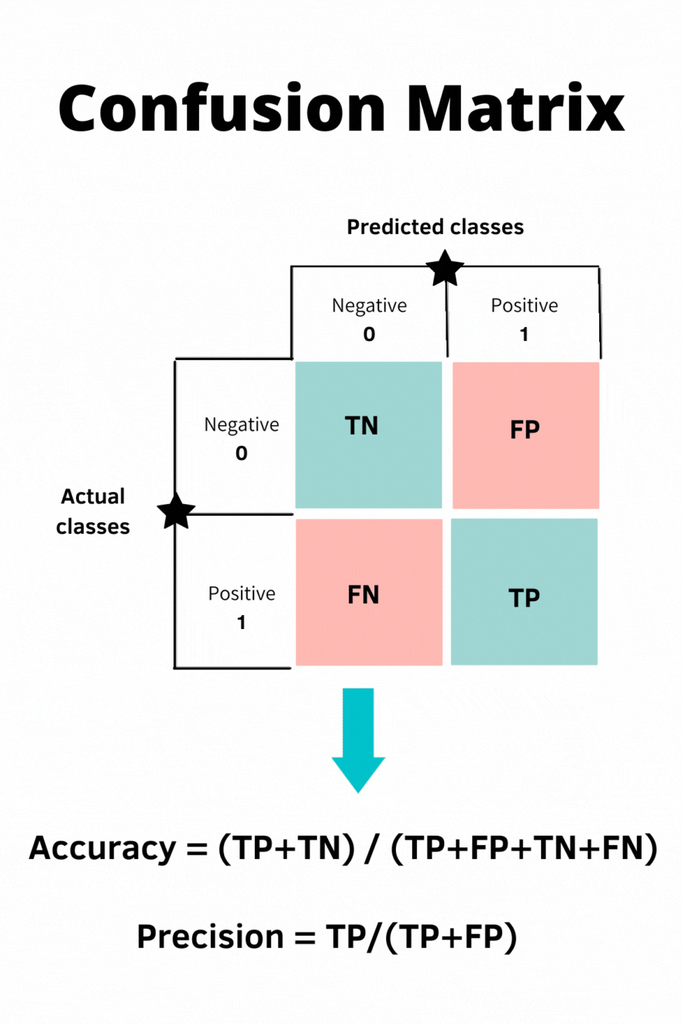

A Confusion matrix is an N x N matrix used for evaluating the performance of a classification model, where N is the number of target classes. The matrix compares the actual target values with those predicted by the machine learning model

```python
# 1st method
from sklearn.metrics import confusion_matrix
confusion_matrix(y_test,y_pred)
```

```
array([[44,  4],
       [ 6, 26]])
```

Compare this matrix with above picture of comfusion matrix then you can see that **44** & **26** are the true values and **4** & **6** are the false value

# Prediction Started

Let's create a function name as **predict_output** to predict the output for new query

```python
def predict_output():
  age=int(input("Enter the age :"))
  salary=int(input("Enter your salary : "))

  # we will convert these two values into numpy array
  # we creating numpy array because these are my inputs for my classifier
  # And we already know when you provide an input it should be need to in 2-D matrix

  return np.array([[age],[salary]]).shape
```

Quickly checking the output of this function

```python
predict_output()
```

```
Enter the age :20
Enter your salary : 20000
```

```
(2, 1)
```

If you remember our shape of **x_train** or **x_test** is *(something,2)* which means we should need **2 columns** but in our case our output shape is *(2,1)* which have only **1 columns** So, what should we do? For that we rewrite the above code again and **reshaping the shape** of our numpy array

```python
def predict_output():
  age=int(input("Enter the age :"))
  salary=int(input("Enter your salary : "))

  # Reshaping the numpy array from (2,1) to (1,2) & store it in new variable

  x_new=np.array([[age],[salary]]).reshape(1,2)

  # Now we scale down the salary of in the range of age
  # which we already learn in same way we also do here

  x_new=scalar.transform(x_new)

  if knn.predict(x_new)[0]==0:
    return "Will not purchase"

  else:
    return "Will purchase"
```

```python
predict_output()
```

```
Enter the age :20
Enter your salary : 500000
```

```
'Will purchase'
```

source : [campusX K Nearest Neighbors Playlist](https://www.youtube.com/watch?v=eDq8rpv6dAo&list=PLKnIA16_RmvZiE-lEdN5RDi18-u-T43zd&index=4)